# zad10_art_v11_eng

```python
# import pandas
import pandas as pd
```

```python
# Import modułów do wizualizacji
import matplotlib.pyplot as plt
import seaborn as sns
import numpy as np
```

```python
# --- GLOBALNY STYL ---
sns.set_theme(
    style="whitegrid",
    context="notebook",
    font_scale=1.2,
    rc={
        "figure.figsize": (8, 5),
        "axes.titlesize": 16,
        "axes.labelsize": 13,
        "axes.titlepad": 15,
        "axes.edgecolor": "#333333",
        "axes.linewidth": 1.0,
        "grid.color": "#DDDDDD",
        "grid.linestyle": "--",
        "grid.linewidth": 0.6,
    }
)

# Paleta kolorów spójna dla całego artykułu
PALETA = ["#4C72B0", "#55A868", "#C44E52", "#8172B2", "#CCB974", "#64B5CD"]
sns.set_palette(PALETA)
```

```python
PALETA_TABEL = sns.color_palette("pastel")
CMAP_PASTEL = sns.light_palette(PALETA_TABEL[0], as_cmap=True)
```

```python
# styl tabel
def styl_tabeli(df, caption=None, width="60%"):
    num_cols = df.select_dtypes(include="number").columns

    styler = (
        df.style
        .format({col: "{:.1f}" for col in num_cols})
        .background_gradient(cmap=CMAP_PASTEL, axis=0)
        .set_properties(**{
            "font-size": "10px",
            "border": "1px solid #DDD",
            "border-collapse": "collapse",
            "padding": "4px",
        })
        .set_table_styles([
            {"selector": "th", "props": [
                ("background-color", PALETA_TABEL[1]),
                ("color", "#333"),
                ("font-size", "10px"),
                ("padding", "4px"),
                ("border-bottom", "2px solid #AAA")
            ]},
            {"selector": "td", "props": [
                ("border", "1px solid #EEE"),
                ("padding", "6px")
            ]},
            {"selector": "table", "props": [
                ("border-collapse", "separate"),
                ("border-spacing", "0px 4px"),
                ("width", width),
                ("margin", "10px 0px")
            ]},
            {"selector": "caption", "props": [
                ("caption-side", "top"),
                ("font-size", "15px"),
                ("font-weight", "bold"),
                ("color", "#444"),
                ("padding", "8px")
            ]}
        ])
    )

    if caption:
        styler = styler.set_caption(caption)

    return styler
```

```python
# Wczytujemy plik '25__iris.csv' z danymi i tworzymy DataFrame (df).
df = pd.read_csv('25__iris.csv', sep=",")
```

```python
# Zmieniamy nazwy kolumn

df_1 = df.rename( columns =
               {
                 'długość kielicha (sepal length)': 'Sepal_length',
                 'szerokość kielicha (sepal width)' :'Sepal_width',
                 'długość płatka (petal length)':'Petal_length',
                 'szerokość płatka (petal width)':'Petal_width',
                 'klasa (class)': 'Species'
                 },
               inplace = False)
```

# Understanding the Iris Dataset: From Raw Numbers to Biological Insight

# I Introduction to the Analysis

## 1. Problem Definition: Why Does Classification Matter?

Accurate classification is one of the foundations of machine learning, and the Iris dataset is a perfect educational example. It helps build intuition about data quality, feature separability, and the interpretation of results.

In this article, we explore the anatomical features of iris flowers to identify which characteristics are most useful for distinguishing species. Step by step, we move from raw numbers to meaningful conclusions.

## 2. Purpose and Scope of the Analysis

Our goal is to determine which morphological features—sepal length, sepal width, petal length, and petal width—are most effective for species classification. We want to verify whether the anatomical differences between species are strong enough to support a reliable predictive model.

## 3. Preparing the Environment: First Look at the Data

The dataset contains 150 samples (50 for each of the three species: Iris setosa, Iris versicolor, and Iris virginica). Measurements are given in centimeters and include four features:

- Sepal length
- Sepal width
- Petal length
- Petal width

To get a feel for the dataset, here is a random sample of 15 observations:

## 4. Anatomical features of Iris flowers — sample of observations

```python
# wyświetlam 5 losowych wierszy tabeli
styl_tabeli(
    df_1.sample(15, random_state=42).round(1),
    caption="Anatomical features of Iris flowers"
)
```

Anatomical features of Iris flowers

|  | Sepal_length | Sepal_width | Petal_length | Petal_width | Species |
| --- | --- | --- | --- | --- | --- |
| 73 | 6.1 | 2.8 | 4.7 | 1.2 | Iris-versicolor |
| 18 | 5.7 | 3.8 | 1.7 | 0.3 | Iris-setosa |
| 118 | 7.7 | 2.6 | 6.9 | 2.3 | Iris-virginica |
| 78 | 6.0 | 2.9 | 4.5 | 1.5 | Iris-versicolor |
| 76 | 6.8 | 2.8 | 4.8 | 1.4 | Iris-versicolor |
| 31 | 5.4 | 3.4 | 1.5 | 0.4 | Iris-setosa |
| 64 | 5.6 | 2.9 | 3.6 | 1.3 | Iris-versicolor |
| 141 | 6.9 | 3.1 | 5.1 | 2.3 | Iris-virginica |
| 68 | 6.2 | 2.2 | 4.5 | 1.5 | Iris-versicolor |
| 82 | 5.8 | 2.7 | 3.9 | 1.2 | Iris-versicolor |
| 110 | 6.5 | 3.2 | 5.1 | 2.0 | Iris-virginica |
| 12 | 4.8 | 3.0 | 1.4 | 0.1 | Iris-setosa |
| 36 | 5.5 | 3.5 | 1.3 | 0.2 | Iris-setosa |
| 9 | 4.9 | 3.1 | 1.5 | 0.1 | Iris-setosa |
| 19 | 5.1 | 3.8 | 1.5 | 0.3 | Iris-setosa |

**Table 1**: Anatomical features of Iris flowers — sample observations.

The dataset is complete and perfectly balanced, which makes it ideal for further analysis.

# II. Statistical Profiling of the Species (Numbers)

## 5. Descriptive Statistics: What Do the Numbers Tell Us?

```python
styl_tabeli(
    df_1.describe(),
    caption="Descriptive Statistics"
)
```

Descriptive Statistics

|  | Sepal_length | Sepal_width | Petal_length | Petal_width |
| --- | --- | --- | --- | --- |
| count | 150.0 | 150.0 | 150.0 | 150.0 |
| mean | 5.8 | 3.1 | 3.8 | 1.2 |
| std | 0.8 | 0.4 | 1.8 | 0.8 |
| min | 4.3 | 2.0 | 1.0 | 0.1 |
| 25% | 5.1 | 2.8 | 1.6 | 0.3 |
| 50% | 5.8 | 3.0 | 4.3 | 1.3 |
| 75% | 6.4 | 3.3 | 5.1 | 1.8 |
| max | 7.9 | 4.4 | 6.9 | 2.5 |

**Table 2**: Descriptive statistics for the entire Iris dataset.

**Key insights**:

- **Petal features** show the greatest variability and are highly informative.
- **Sepal features** overlap heavily and offer limited discriminative power.

## 6. Detailed Statistics for Each Species

### 6.1 Setosa: A Pattern of Stability

```python
df_1_setosa = df_1.loc[df_1["Species"]=="Iris-setosa"]
styl_tabeli(
    df_1_setosa.describe(),
    caption="Detailed Statistics - SETOSA"
)
```

Detailed Statistics - SETOSA

|  | Sepal_length | Sepal_width | Petal_length | Petal_width |
| --- | --- | --- | --- | --- |
| count | 50.0 | 50.0 | 50.0 | 50.0 |
| mean | 5.0 | 3.4 | 1.5 | 0.2 |
| std | 0.4 | 0.4 | 0.2 | 0.1 |
| min | 4.3 | 2.3 | 1.0 | 0.1 |
| 25% | 4.8 | 3.1 | 1.4 | 0.2 |
| 50% | 5.0 | 3.4 | 1.5 | 0.2 |
| 75% | 5.2 | 3.7 | 1.6 | 0.3 |
| max | 5.8 | 4.4 | 1.9 | 0.6 |

**Table 3**: Descriptive statistics for Iris Setosa.

**Interpretation**:

- **Setosa** has extremely short and narrow petals, with ranges that do not overlap with any other species.
- **Sepal measurements** are stable and show low variability.

### 6.2. Virginica vs. Versicolor: Giants and Middleweights

**Virginica**

```python
df_1_virginica = df_1.loc[df_1["Species"]=="Iris-virginica"]
styl_tabeli(
    df_1_virginica.describe(),
    caption="Detailed Statistics - VIRGINICA"
)
```

Detailed Statistics - VIRGINICA

|  | Sepal_length | Sepal_width | Petal_length | Petal_width |
| --- | --- | --- | --- | --- |
| count | 50.0 | 50.0 | 50.0 | 50.0 |
| mean | 6.6 | 3.0 | 5.6 | 2.0 |
| std | 0.6 | 0.3 | 0.6 | 0.3 |
| min | 4.9 | 2.2 | 4.5 | 1.4 |
| 25% | 6.2 | 2.8 | 5.1 | 1.8 |
| 50% | 6.5 | 3.0 | 5.5 | 2.0 |
| 75% | 6.9 | 3.2 | 5.9 | 2.3 |
| max | 7.9 | 3.8 | 6.9 | 2.5 |

**Table 4**: Descriptive statistics for Iris Virginica.

**Insights**:

- **Virginica** has the largest anatomical measurements.
- **Petal width** is the most distinctive feature.
- **Petal length** overlaps with Versicolor at the lower end.

**Versicolor**

```python
df_1_versicolor = df_1.loc[df_1["Species"]=="Iris-versicolor"]
styl_tabeli(
    df_1_versicolor.describe(),
    caption="Detailed Statistics - VERSICOLOR"
)
```

Detailed Statistics - VERSICOLOR

|  | Sepal_length | Sepal_width | Petal_length | Petal_width |
| --- | --- | --- | --- | --- |
| count | 50.0 | 50.0 | 50.0 | 50.0 |
| mean | 5.9 | 2.8 | 4.3 | 1.3 |
| std | 0.5 | 0.3 | 0.5 | 0.2 |
| min | 4.9 | 2.0 | 3.0 | 1.0 |
| 25% | 5.6 | 2.5 | 4.0 | 1.2 |
| 50% | 5.9 | 2.8 | 4.3 | 1.3 |
| 75% | 6.3 | 3.0 | 4.6 | 1.5 |
| max | 7.0 | 3.4 | 5.1 | 1.8 |

**Table 5**: Descriptive statistics for Iris Versicolor.

**Insights**:

- **Versicolor** occupies the middle ground between Setosa and Virginica.
- **Petal features** again dominate.
- Both petal length and width overlap with Virginica.
- **Sepal width** is the least informative feature.

### 6.3. Summary of the Numerical Stage

Setosa is completely isolated. Versicolor and Virginica partially overlap. Petal features drive classification; sepal features provide little separation.

## 7. Analysis of Mean Values

## 7. Feature Hierarchy

To complete the statistical picture, we compare the mean values of all features across the three examined species. This “top‑down” overview allows us to confirm our earlier observations with numerical evidence.

```python
# tworze tabele srednich wartosci
df_summary_stat = pd.DataFrame({
    "Species": ["Setosa", "Versicolor", "Virginica"],
    "Sepal_length": [5.01, 5.94, 6.59],
    "Sepal_widthr": [3.42, 2.77, 2.97],
    "Petal_length": [1.46, 4.26, 5.55],
    "Petal_width": [0.24, 1.33, 2.03]
})
```

### 7.1. Comparison of Mean Values for the Three Species

```python
# rysuje tabele
styl_tabeli(
    df_summary_stat,
    caption="Comparison of Mean Values for the Three Species"
)
```

Comparison of Mean Values for the Three Species

|  | Species | Sepal_length | Sepal_widthr | Petal_length | Petal_width |
| --- | --- | --- | --- | --- | --- |
| 0 | Setosa | 5.0 | 3.4 | 1.5 | 0.2 |
| 1 | Versicolor | 5.9 | 2.8 | 4.3 | 1.3 |
| 2 | Virginica | 6.6 | 3.0 | 5.5 | 2.0 |

**Table 6**: Comparison of Mean Values for the Three Species.

### 7.2. Feature Hierarchy: What Truly Differentiates the Irises?

Based on the values above, we can rank the features according to their discriminative power (their ability to separate the species):

- **Petal Width** — The clear leader.
- **Petal Length** — The key supporting feature.
- **Sepal Features** — Analytical background rather than decisive factors.

### 7.3. Key Conclusions from the Statistical Stage

- **Isolation of Setosa**: This is the most homogeneous and completely separated species. In practical Data Science terms, misclassifying Setosa is extremely rare.
- **Neighborhood of Versicolor and Virginica**: These two species are “anatomical neighbors.” Their proximity and partial overlap in petal characteristics account for most algorithmic misclassifications.
- **Dominance of Petal Features**: The analysis clearly shows that it is petal morphology—not sepal morphology—that holds the key to understanding the diversity of irises.

# III Visual Exploration 1D (Histograms)

## 8. From Statistics to Visuals: The Philosophy of Visualization

Numbers give us structure, but visualizations reveal the true shape of the data. We begin by verifying dataset balance — the species distribution plot confirms that the dataset is perfectly balanced.

### 8.1. Species count distribution

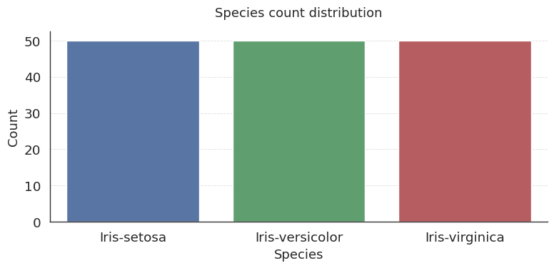

```python
# Ustawienie rozmiaru: np. 12 cali szerokości i 6 cali wysokości
fig, ax = plt.subplots(figsize=(8, 4))

sns.countplot(x='Species', data=df_1, hue='Species', ax=ax)

ax.set_title("Species count distribution", fontsize=13) # Możesz też powiększyć czcionkę tytułu
ax.set_xlabel("Species", fontsize=13)
ax.set_ylabel("Count", fontsize=13)

sns.despine()
plt.tight_layout()
plt.show()
```

**Figure 1**: Species count distribution.

### 8.2. Histograms: What Does the “General View” Hide?

Looking at all species together helps us identify natural groupings.

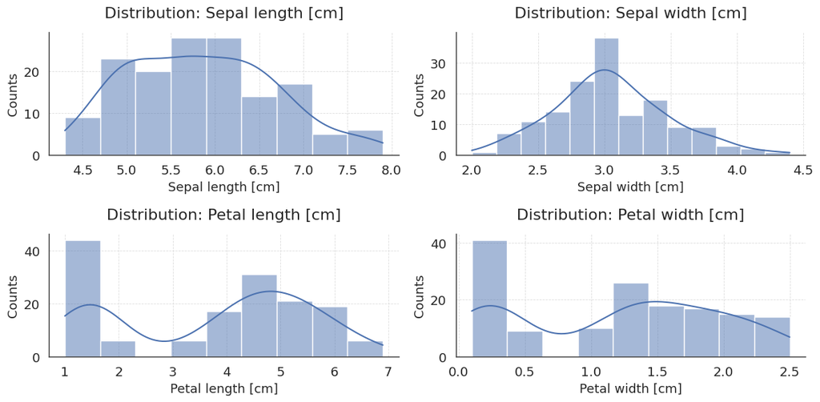

```python
fig, axes = plt.subplots(2, 2, figsize=(12, 6))

kolumny = [
    ("Sepal_length", "Sepal length [cm]"),
    ("Sepal_width", "Sepal width [cm]"),
    ("Petal_length", "Petal length [cm]"),
    ("Petal_width", "Petal width [cm]")
]

for ax, (col, label) in zip(axes.flatten(), kolumny):
    sns.histplot(df_1[col], kde=True, ax=ax)
    ax.set_title(f"Distribution: {label}")
    ax.set_xlabel(label)
    ax.set_ylabel("Counts")
    sns.despine(ax=ax)

plt.tight_layout()
plt.show()
```

**Figure 2**: Four histograms of feature distributions.

### 8.4. Conclusions from Distribution Analysis

# IV Detailed Analysis of Distributions

## 9. Sepal Features: Detecting Noise?

We begin with the features that descriptive statistics identified as the least informative.

### 9.1. Sepal Length Distribution for the Three Species

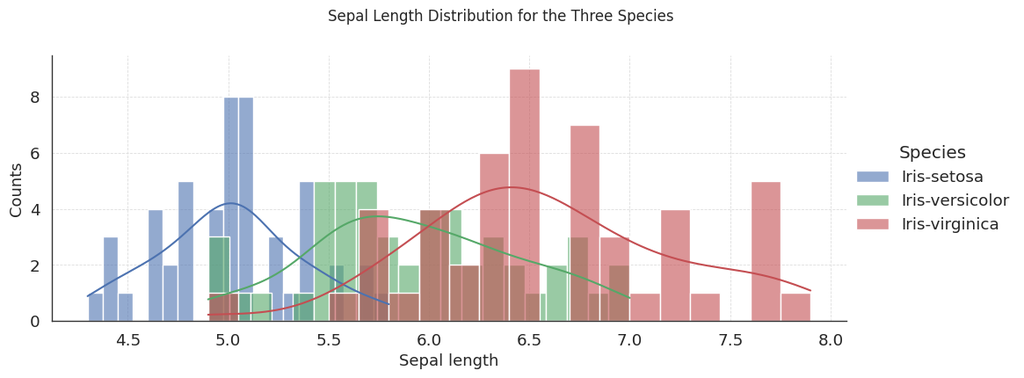

```python
g = sns.FacetGrid(df_1, hue="Species", height=4, aspect=2.5, palette=PALETA)
g.map(sns.histplot, "Sepal_length", kde=True, bins=20, alpha=0.6)
g.add_legend()

# Dodaj tę linię, aby zmienić nazwy osi:
g.set_axis_labels("Sepal length", "Counts")

g.fig.suptitle("Sepal Length Distribution for the Three Species", y=1.08, fontsize=12)

plt.show()
```

**Figure 3**: Distribution of sepal length for the three species.

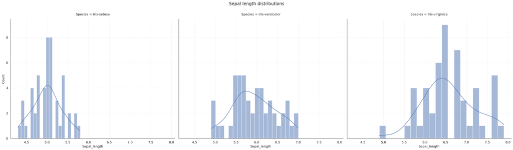

```python
# Rozkład długości kielicha dla każdego gatunku osobno
g = sns.FacetGrid(df_1, col="Species", height=8, aspect=1.2, palette=PALETA)
g.map(sns.histplot, "Sepal_length", kde=True, bins=20)
g.fig.suptitle("Sepal length distributions", y=1.05)
```

**Figure 4**: Sepal length distributions — shown separately for each species.

### 9.2. Conclusions

The detailed analysis confirms that sepal length has low discriminative power.

Although the overall histogram shows non-uniformity, only the species-level breakdown reveals the cause: Setosa overlaps heavily with Versicolor, and Versicolor is nearly indistinguishable from Virginica. Virginica is slightly shifted toward higher values, but the separation is too weak to support reliable classification.

### 9.3. Sepal Width — The Least Informative Feature

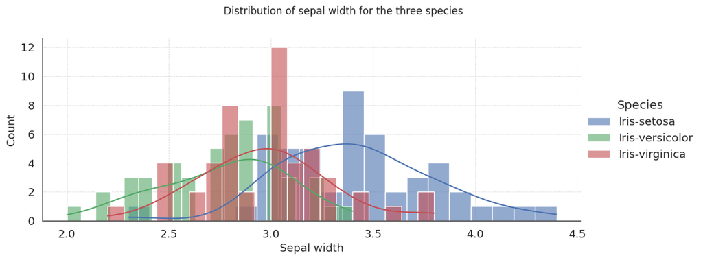

```python
g = sns.FacetGrid(df_1, hue="Species", height=4, aspect=2.5, palette=PALETA)
g.map(sns.histplot, "Sepal_width", kde=True, bins=20, alpha=0.6)
g.add_legend()

# Dodaj tę linię, aby zmienić nazwy osi:
g.set_axis_labels("Sepal width", "Count")

g.fig.suptitle("Distribution of sepal width for the three species", y=1.08, fontsize=12)

plt.show()
```

**Figure 5**: Distribution of sepal width for the three species.

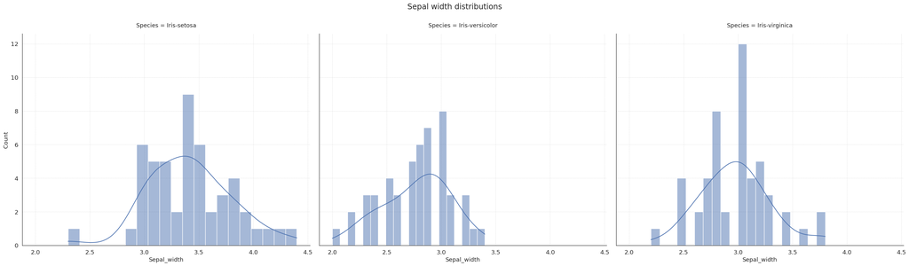

```python
# Rozkład szerokości kielicha dla każdego gatunku osobno
g = sns.FacetGrid(df_1, col="Species", height=8, aspect=1.2, palette=PALETA)
g.map(sns.histplot, "Sepal_width", kde=True, bins=20)
g.fig.suptitle("Sepal width distributions", y=1.05)
```

**Figure 6**: Sepal width distributions — shown separately for each species.

### 9.4. What do we see?

**Conclusion**: Sepal width is informational noise. Machine learning models treat it as a secondary feature because it offers no clear boundaries between classes.

### 9.6. Petals: The Biological Key to Iris Classification

We now analyze the features that earlier statistics identified as decisive. This is where the “general to specific” method produces the most striking results.

### 9.7. Petal Length: The First Clear Separation

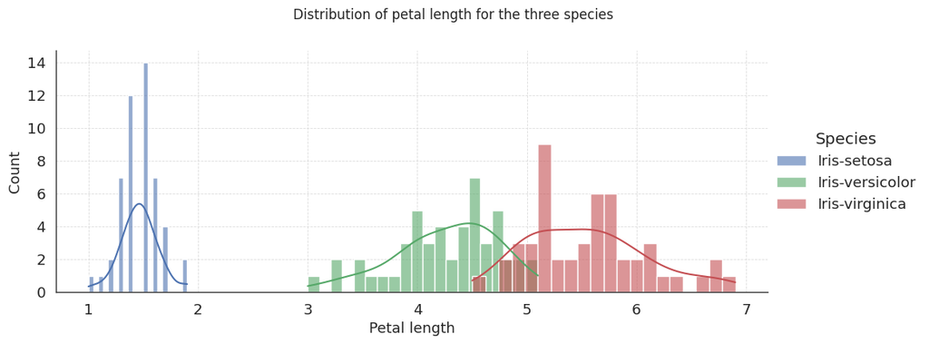

```python
g = sns.FacetGrid(df_1, hue="Species", height=4, aspect=2.5, palette=PALETA)
g.map(sns.histplot, "Petal_length", kde=True, bins=20, alpha=0.6)
g.add_legend()

# Dodaj tę linię, aby zmienić nazwy osi:
g.set_axis_labels("Petal length", "Count")

g.fig.suptitle("Distribution of petal length for the three species", y=1.08, fontsize=12)

plt.show()
```

**Figure 7**: Distribution of petal length for the three species.

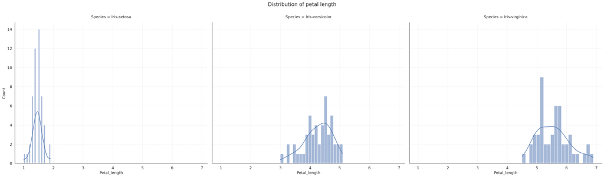

```python
# Rozkład długości płatka dla każdego gatunku osobno
g = sns.FacetGrid(df_1, col="Species", height=8, aspect=1.2, palette=PALETA)
g.map(sns.histplot, "Petal_length", kde=True, bins=20)
g.fig.suptitle("Distribution of petal length", y=1.05)
```

**Figure 8**: Petal length distributions — shown separately for each species.

**Key observations**:

- Setosa is perfectly isolated — a narrow, tall peak (1.0–1.9 cm) completely separated from the rest.
- Contact zone — Versicolor and Virginica overlap around 4.5–5.1 cm.
- KDE curve — not a Gaussian bell, but a sum of three distinct distributions, confirming three biological populations.

### 9.8. Petal Width — The Most Powerful Predictor

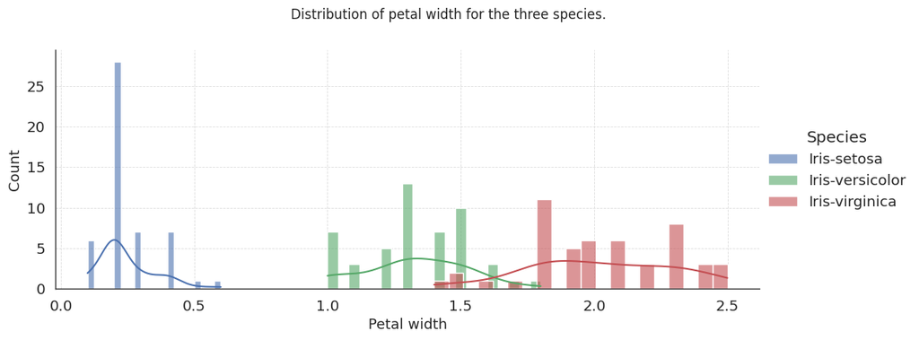

```python
g = sns.FacetGrid(df_1, hue="Species", height=4, aspect=2.5, palette=PALETA)
g.map(sns.histplot, "Petal_width", kde=True, bins=20, alpha=0.6)
g.add_legend()

# Dodaj tę linię, aby zmienić nazwy osi:
g.set_axis_labels("Petal width", "Count")

g.fig.suptitle("Distribution of petal width for the three species.", y=1.08, fontsize=12)

plt.show()
```

**Figure 9**: Distribution of petal width for the three species.

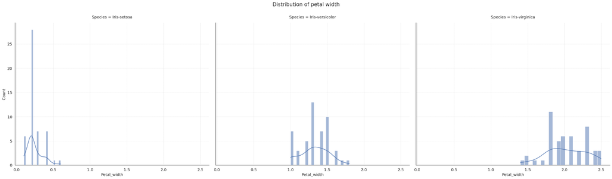

```python
# Rozkład szerokości płatka dla kazdego z gatunków osobno
g = sns.FacetGrid(df_1, col="Species", height=8, aspect=1.2, palette=PALETA)
g.map(sns.histplot, "Petal_width", kde=True, bins=20)
g.fig.suptitle("Distribution of petal width", y=1.05)
```

**Figure 10**: Petal width distributions — shown separately for each species.

### 9.10 Summary of Petal Analysis

While sepal features introduce noise, petal features provide a clean signal. Setosa is an “island,” while Versicolor and Virginica are “peninsulas” connected by a narrow strip of shared values.

Petal length and width form the foundation of Iris classification.

# V Relationship Analysis (Scatterplots and Pairplots)

## 10. Scatterplot - Feature Space: Why 1D Is Not Enough?

Histograms gave us a foundation, but they analyze each feature in isolation. Species, however, are defined by the co-occurrence of features. Scatterplots reveal how sepal and petal parameters interact in two-dimensional space.

### 10.1. Sepal Feature Relationships

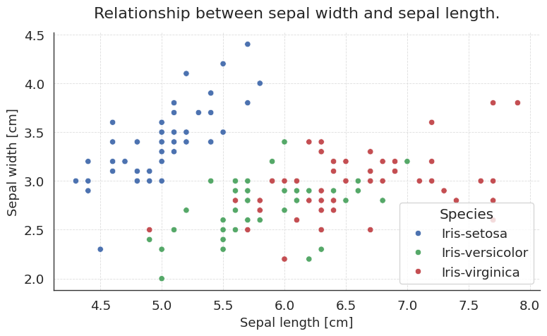

```python
# Realacje pomiędzy szerokością a długością kielicha
fig, ax = plt.subplots(figsize=(8, 5))

sns.scatterplot(x='Sepal_length', y='Sepal_width', hue='Species', data=df_1, ax=ax )

ax.set_title("Relationship between sepal width and sepal length.")
ax.set_xlabel("Sepal length [cm]")
ax.set_ylabel("Sepal width [cm]")

sns.despine()
plt.tight_layout()
plt.show()
```

**Figure 11**: Relationship between sepal width and sepal length.

### 10.3. Why This “Negative” Result Matters

The conclusion from histograms is confirmed in 2D: **sepals are background; petals are the key**.

### 10.4. The True Structure in 2D: Petal Length vs. Petal Width

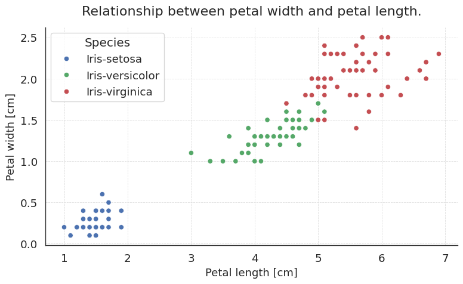

```python
# Relacje pomiędzy szerokością a długością płatka
fig, ax = plt.subplots(figsize=(8, 5))

sns.scatterplot(x='Petal_length', y='Petal_width', hue='Species', data=df_1, ax=ax )

ax.set_title("Relationship between petal width and petal length.")
ax.set_xlabel("Petal length [cm]")
ax.set_ylabel("Petal width [cm]")

sns.despine()
plt.tight_layout()
plt.show()
```

**Figure 12**: Relationship between petal width and petal length.

### 10.5. Why this plot is groundbreaking:

- **Three clear clusters** — Setosa forms a tight, isolated group.
- **Boundary zone** — Versicolor and Virginica touch but do not fully mix.
- **Petals dominate** — compared to the chaotic sepal scatterplot, this one is clean and structured.

### 10.6. Summary of Scatterplot Insights

This is the most important visualization in the entire analysis. The “general to specific” path revealed not only how to classify Iris species, but why some are harder to distinguish.

The Iris dataset teaches a fundamental lesson: visualization is not an accessory — it is a tool for understanding the problem before writing a single line of model code.

## 11. Pairplot: A Synthetic Multidimensional View

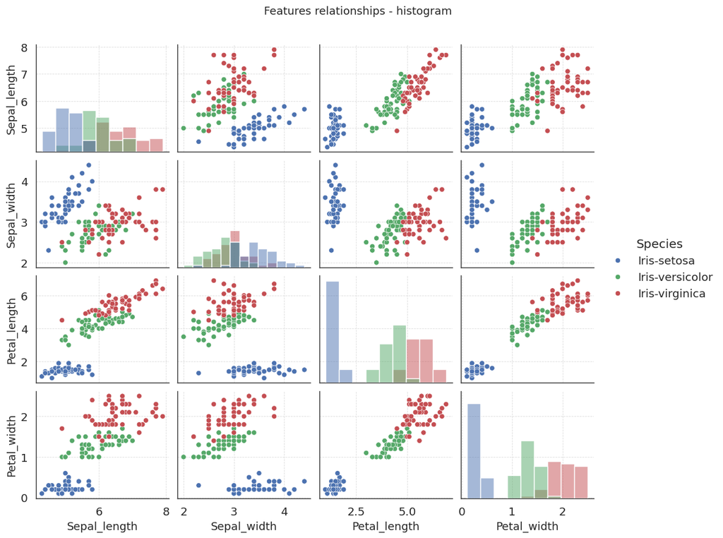

```python
g = sns.pairplot(df_1, hue='Species', diag_kind='hist', height=2.1, aspect=1.2)

# Poprawienie tytułu, aby nie nachodził na wykres (y=1.02)
g.fig.suptitle("Features relationships - histogram", y=1.05, fontsize=13)

plt.show()
```

**Figure 13**: Pairplot — histogram view.

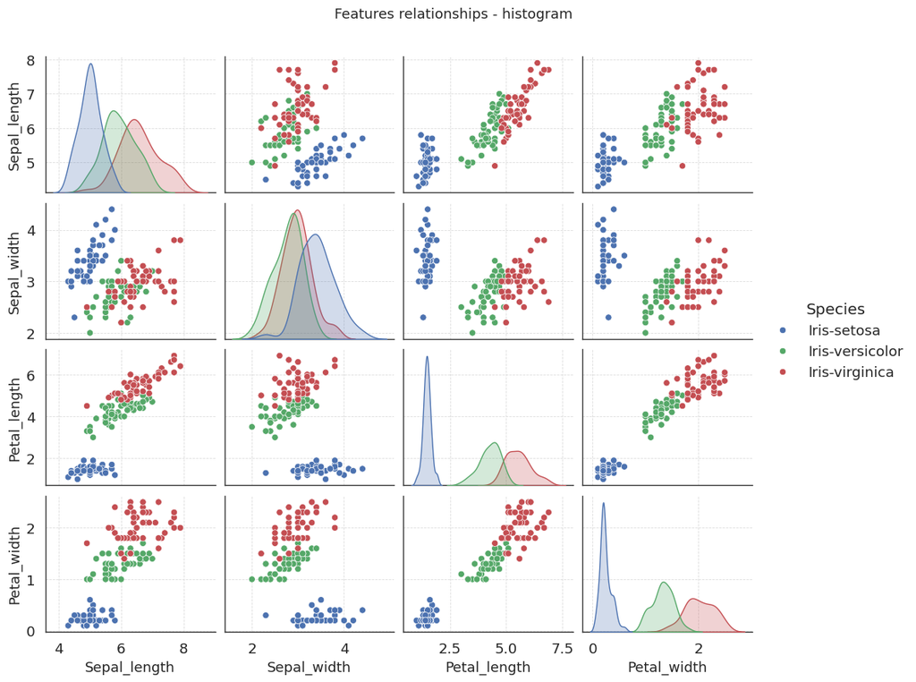

```python
g = sns.pairplot(df_1, hue='Species', diag_kind='kde', height=2.1, aspect=1.2)

# Poprawienie tytułu, aby nie nachodził na wykres (y=1.02)
g.fig.suptitle("Features relationships - histogram", y=1.05, fontsize=13)

plt.show()
```

**Figure 14**: Pairplot — KDE view.

### 11.1. The Final Multidimensional Proof

**What the pairplot reveals**:

- **Setosa isolation** — in every petal-related plot, Setosa forms a tight, separate cluster.
- **The difficult pair** — Versicolor and Virginica touch in specific regions.
- **Feature hierarchy** — petal plots show order; sepal plots show chaos.

### 11.2. Why Pairplot Completes the Journey

We now understand not only that Setosa is easy to classify and Virginica/Versicolor are often confused — we understand why, down to the exact centimeters and overlap zones.

# VI Diagnostics and Data Verification (Heatmap and Boxplots)

## 12. Mathematical Verification of Correlations

After reviewing dozens of scatterplots, we now ask a crucial question: what is the numerical strength of these relationships? The answer comes from the Pearson correlation matrix, visualized as a heatmap. This is where we “see” the mathematical structure of the Iris dataset.

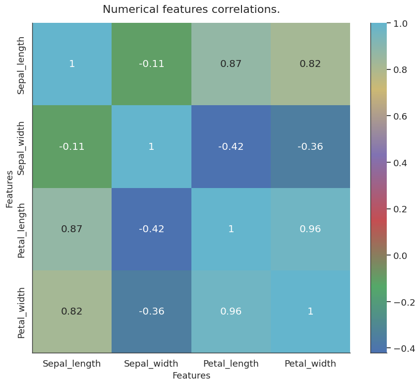

```python
# heatmap
from matplotlib.colors import LinearSegmentedColormap

cmap_custom = LinearSegmentedColormap.from_list("moj_cmap", PALETA)

fig, ax = plt.subplots(figsize=(9, 8))

sns.heatmap(df_1.select_dtypes(include=['number']).corr(method='pearson'),
            annot = True, cmap=cmap_custom);

ax.set_title("Numerical features correlations.")
ax.set_xlabel("Features")
ax.set_ylabel("Features")

sns.despine()
plt.tight_layout()
plt.show()
```

**Figure 15**: Heatmap of numerical feature correlations.

### 12.1. Mathematical Proof of Feature Hierarchy

**Sepal as the “Shadow” of the Petal (0.87 and 0.82)**:

- Sepal length correlates strongly with petal dimensions.
- However, it remains a secondary carrier of information — the petals express the same structure more clearly.

### 12.2. Why the Heatmap Matters

The heatmap allows us to mentally reduce dimensionality. Since petal length and width are so strongly correlated, they carry nearly the same information. This confirms what we saw in scatterplots: the Iris dataset is effectively low-dimensional. Just two petal features are enough to describe all 150 flowers with high precision.

## 13. Data Robustness: Boxplots and Outlier Detection

We now turn to the final tool in our diagnostic arsenal — boxplots. While histograms showed the “mountains” of data, boxplots allow us to precisely evaluate medians, quartiles, and identify outliers that might confuse models.

### 13.1. All Features Together (No Species Split)

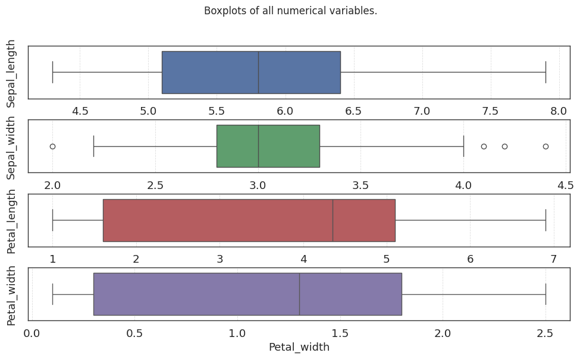

```python
# Rozkład zmiennych numerycznych
num_cols = df_1.select_dtypes(include=['number']).columns
n = len(num_cols)

fig, axes = plt.subplots(n, 1, figsize=(10, 1.5*n), sharex=False)

for ax, col, color in zip(axes, num_cols, PALETA):
    sns.boxplot(
        data=df_1,
        x=col,
        ax=ax,
        color=color
    )
    ax.set_ylabel(col)      # <-- zamiast tytułu
    ax.set_title("")        # <-- wyłącz tytuł

fig.suptitle("Boxplots of all numerical variables.", fontsize=12, y=1.01)

plt.tight_layout()
fig.subplots_adjust(hspace=0.4)
```

**Figure 16**: Boxplots of all numerical variables.

### 13.2. Initial observations:

- Petal features show large variability and wide ranges — the heart of species separation lies here.
- Sepal width is the most compact feature (small box), yet the only one with visible outliers.

### 13.3. Detailed Analysis: Sepal Under the Microscope

Following our methodology, we now break down boxplots by species to evaluate their true discriminative power.

**Sepal Length**

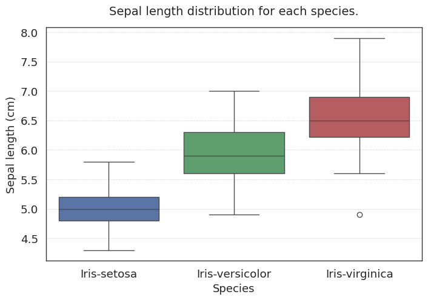

```python
#import matplotlib.pyplot as plt # Upewnij się, że nie nadpisałeś tej nazwy wcześniej

# 1. Ustawienie rozmiaru (szerokość 10, wysokość 6 cali)
plt.figure(figsize=(8, 5))

# 2. Tworzenie wykresu (nie przypisuj go do nazwy 'plt'!)
ax = sns.boxplot(
    x='Species',
    y='Sepal_length',
    data=df_1,
    order=["Iris-setosa", "Iris-versicolor", "Iris-virginica"],
    hue="Species",
    palette=PALETA[:3]
)

# 3. Dodanie tytułu i etykiet przez obiekt 'ax'
ax.set_title("Sepal length distribution for each species.", fontsize=14)
ax.set_ylabel("Sepal length (cm)")
ax.set_xlabel("Species")

plt.show()
```

**Figure 17**: Sepal length distribution for each species.

### 13.4. WConclusion

This is the first key comparative boxplot. It exposes the weakness of this feature with brutal clarity:

**Sepal length alone is insufficient for species identification**.

### 13.5. Sepal Width — The Weakest Link

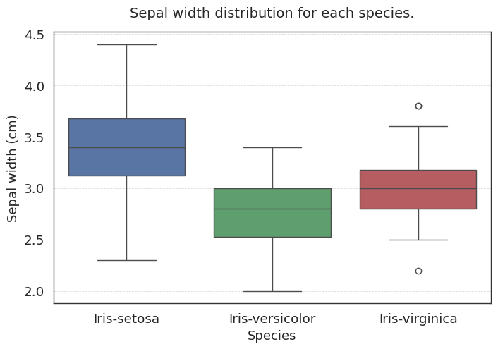

```python
#import matplotlib.pyplot as plt # Upewnij się, że nie nadpisałeś tej nazwy wcześniej

# 1. Ustawienie rozmiaru (szerokość 10, wysokość 6 cali)
plt.figure(figsize=(8, 5))

# 2. Tworzenie wykresu (nie przypisuj go do nazwy 'plt'!)
ax = sns.boxplot(
    x='Species',
    y='Sepal_width',
    data=df_1,
    order=["Iris-setosa", "Iris-versicolor", "Iris-virginica"],
    hue="Species",
    palette=PALETA[:3]
)

# 3. Dodanie tytułu i etykiet przez obiekt 'ax'
ax.set_title("Sepal width distribution for each species.", fontsize=14)
ax.set_ylabel("Sepal width (cm)")
ax.set_xlabel("Species")

plt.show()
```

**Figure 18**: Sepal width distribution for each species.

### 13.6. Why this plot is paradoxically important:

Sepal width is the least useful feature in the entire dataset — a perfect example of how some data dimensions contribute noise rather than signal.

### 13.7. Petals Under the Microscope: Where Uncertainty Ends

We now analyze the boxplots of petal features — the heart of the dataset. This is where the “general to specific” method reveals the true biological structure of the data.

**Petal Length**

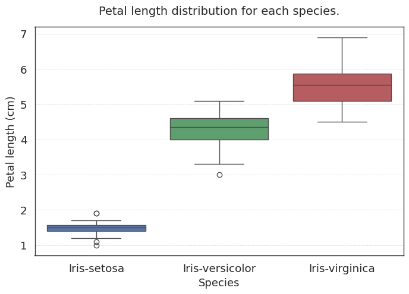

```python
import matplotlib.pyplot as plt # Upewnij się, że nie nadpisałeś tej nazwy wcześniej

# 1. Ustawienie rozmiaru (szerokość 10, wysokość 6 cali)
plt.figure(figsize=(8, 5))

# 2. Tworzenie wykresu (nie przypisuj go do nazwy 'plt'!)
ax = sns.boxplot(
    x='Species',
    y='Petal_length',
    data=df_1,
    order=["Iris-setosa", "Iris-versicolor", "Iris-virginica"],
    hue="Species",
    palette=PALETA[:3]
)

# 3. Dodanie tytułu i etykiet przez obiekt 'ax'
ax.set_title("Petal length distribution for each species.", fontsize=14)
ax.set_ylabel("Petal length (cm)")
ax.set_xlabel("Species")

plt.show()
```

**Figure 19**: Petal length distribution for each species.

**Key observations**:

- **Setosa is perfectly isolated**.
- **Critical overlap zone** — Versicolor (up to 5.1 cm) and Virginica (from 4.5 cm).
- This 0.6 cm shared range is the main source of classification errors.

**Petal Width — The Crown Jewel**

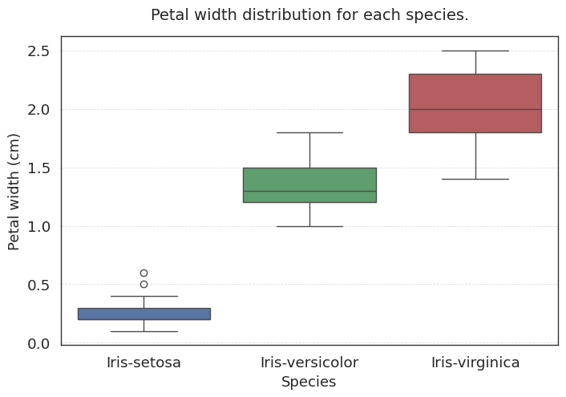

```python
import matplotlib.pyplot as plt # Upewnij się, że nie nadpisałeś tej nazwy wcześniej

# 1. Ustawienie rozmiaru (szerokość 10, wysokość 6 cali)
plt.figure(figsize=(8, 5))

# 2. Tworzenie wykresu (nie przypisuj go do nazwy 'plt'!)
ax = sns.boxplot(
    x='Species',
    y='Petal_width',
    data=df_1,
    order=["Iris-setosa", "Iris-versicolor", "Iris-virginica"],
    hue="Species",
    palette=PALETA[:3]
)

# 3. Dodanie tytułu i etykiet przez obiekt 'ax'
ax.set_title("Petal width distribution for each species.", fontsize=14)
ax.set_ylabel("Petal width (cm)")
ax.set_xlabel("Species")

plt.show()
```

**Figure 20**: Petal width distribution for each species.

**If we had to choose only one column from the entire dataset for classification, petal width would be the winner**.

# VII Summary and Conclusions

## 14. What the Iris Dataset Has Taught Us

We have traveled from raw descriptive statistics, through the noisy world of sepal features, to the clean and orderly structure revealed by petal features. This journey highlights several fundamental lessons about data, biology, and classification.

**Information hierarchy**:

- Petal features are the signal — they carry the essential biological structure needed for classification.
- Sepal features are largely noise — they overlap heavily and contribute little to species separation.
- Petal width, with its correlation of 0.96 to petal length, is both a mathematical and visual leader.

**Understanding model errors**:

- Visualization reveals exactly why models do not reach 100% accuracy.
- The limitation is biological, not algorithmic — a narrow overlap between Versicolor and Virginica in specific measurement ranges.

**The power of visualization**:

- Boxplots and pairplots allow us to see what tables only hint at.
- The Iris dataset, though simple, is an ideal playground for learning about clusters, separability, and outliers.
- This is foundational knowledge for anyone entering Data Science.

## 15. Did We Achieve Our Goal?

Yes. Our goal was to identify the features that enable accurate species classification in the Iris dataset. The conclusion is clear and supported by every analytical step:

- **Petal features are essential** for classification.
- **Sepal features are secondary** and provide only supporting context. The Iris dataset remains a timeless example not because it is simple, but because it teaches the core principles of exploratory data analysis, feature importance, and the biological meaning behind numbers.